# Estimates of nativelikeness among L2 speakers can’t be interpreted: Code

Jan Vanhove (jan.vanhove@unifr.ch, http://janhove.github.io/)

August 31, 2019

This is the online accompaniment to my talk *Estimates of nativelikeness among L2 speakers can’t be interpreted: The problem and two solutions* at [EuroSLA 29](https://www.eurosla2019.se/). The talk is based on my article [*When labeling L2 users as nativelike or not, consider classification errors*](https://doi.org/10.1177%2F0267658319827055) (Vanhove 2019), but this accompaniment contains some additional material. You can download the slides for the talk [here](https://janhove.github.io/nativelike/2019_eurosla_vanhove.pdf).

The simulation code for the “How bad could it be?” slides is available from https://osf.io/pxefv/. For the talk, I adapted the sample sizes from 8, 32 and 128 to 15 and 50, which are the median and maximum sample sizes found in Andringa’s (2014) survey. (Only the results for $n = 15$ are shown in the slides.)

All analyses below were run in R. See the bottom of this page for the software versions.

# 1 Preliminaries

```r
# Load packages
library(tidyverse)
library(caret)
```

# 2 Illustrations for talk

## 2.1 Assessing nativelikeness

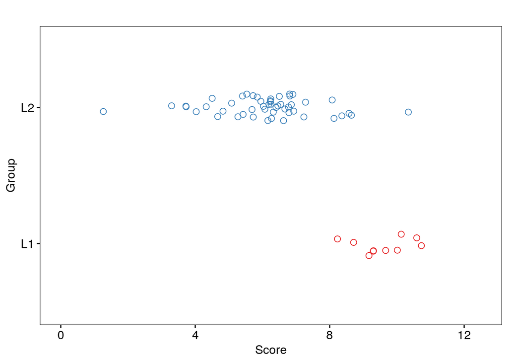

```r
# Set seed for random number generator
set.seed(314)

# Generate tasks scores
L1_in_study <- rnorm(10) + 10
L2_in_study <- rt(50, df = 2) + 6
L1_not_in_study <- rnorm(200) + 10

df <- data.frame(Group = c(rep("L1", 10),
                           rep("L2", 50)),
                 Score = c(L1_in_study, L2_in_study))

p1 <- ggplot(df,
       aes(x = Score,
           y = Group,
           colour = Group)) +
  geom_point(shape = 1, position = position_jitter(height = 0.1),
             size = 2.5) +
  scale_colour_manual(values = c("#E41A1C", "#377EB8")) +
  theme(legend.position = "none") +
  xlim(0, 12.5)

p1 + ggtitle("")
```

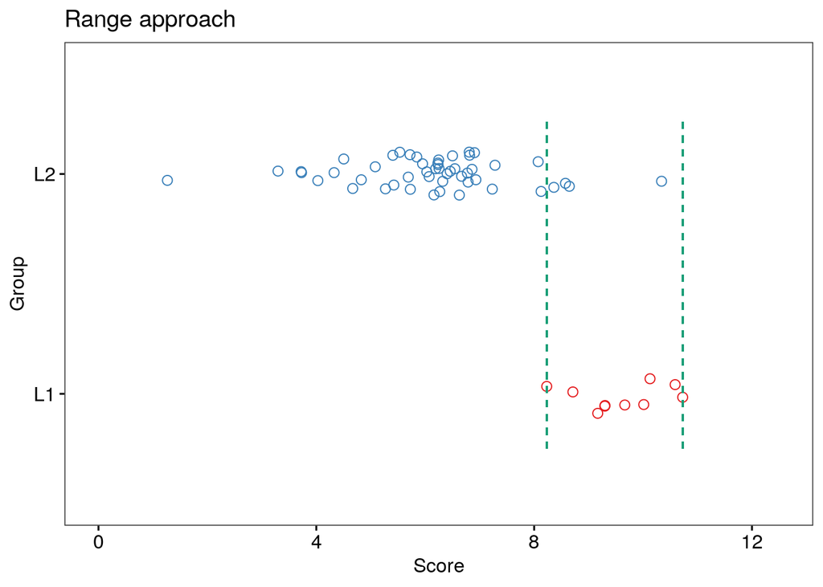

```r
p1 +
  geom_segment(aes(x = min(L1_in_study),
                   xend = min(L1_in_study),
                   y = 0.75, yend = 2.25),
               colour = "#1B9E77",
               linetype = 2) +
  geom_segment(aes(x = max(L1_in_study),
                   xend = max(L1_in_study),
                   y = 0.75, yend = 2.25),
               colour = "#1B9E77",
               linetype = 2) +
  ggtitle("Range approach")
```

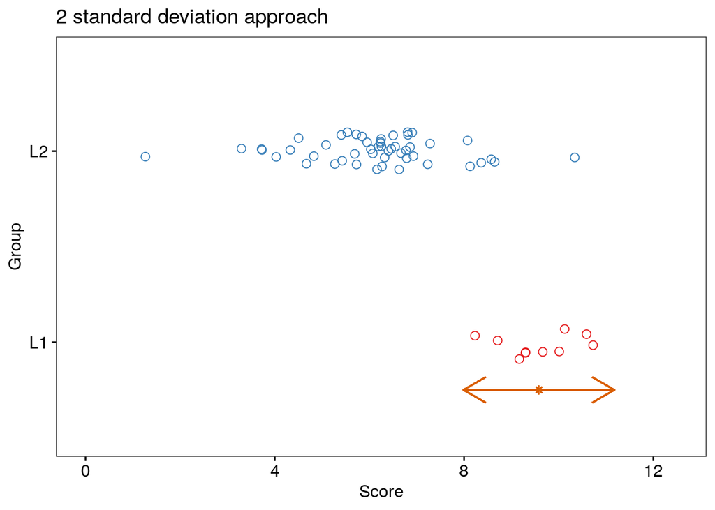

```r
p1 +
  geom_point(x = mean(L1_in_study),
             y = 0.75,
             shape = 8,
             colour = "#D95F02") +
  geom_segment(x = mean(L1_in_study),
               xend = mean(L1_in_study) + 2 * sd(L1_in_study),
               y = 0.75, yend = 0.75,
               colour = "#D95F02",
               arrow = arrow()) +
  geom_segment(x = mean(L1_in_study),
               xend = mean(L1_in_study) - 2 * sd(L1_in_study),
               y = 0.75, yend = 0.75,
               colour = "#D95F02",
               arrow = arrow()) +
  ggtitle("2 standard deviation approach")
```

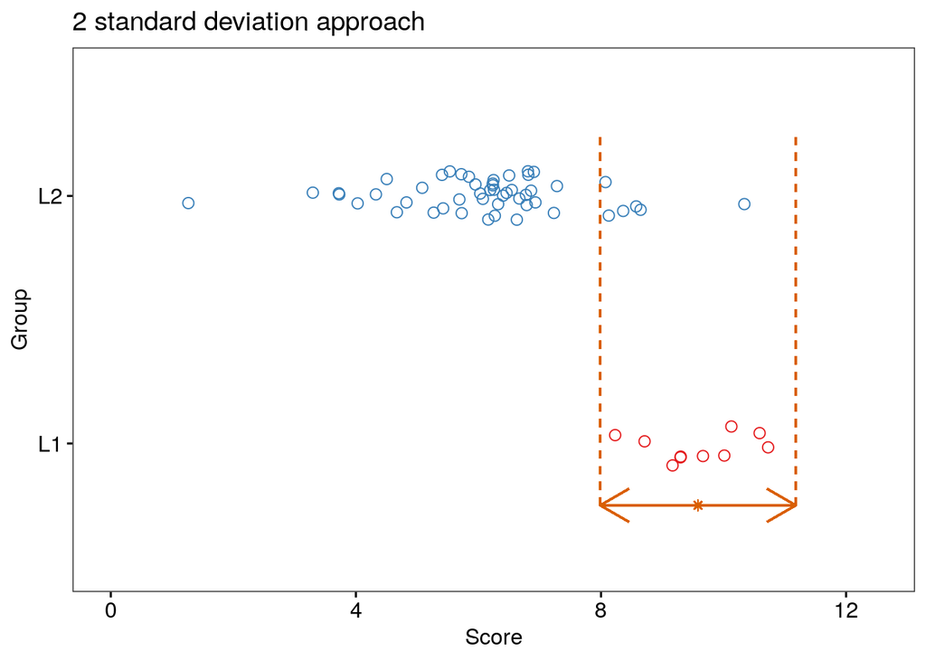

```r
p1 +
  geom_point(x = mean(L1_in_study),
             y = 0.75,
             shape = 8,
             colour = "#D95F02") +
  geom_segment(x = mean(L1_in_study),
               xend = mean(L1_in_study) + 2 * sd(L1_in_study),
               y = 0.75, yend = 0.75,
               colour = "#D95F02",
               arrow = arrow()) +
  geom_segment(x = mean(L1_in_study),
               xend = mean(L1_in_study) - 2 * sd(L1_in_study),
               y = 0.75, yend = 0.75,
               colour = "#D95F02",
               arrow = arrow()) +
  geom_segment(aes(x = mean(L1_in_study) - 2 * sd(L1_in_study),
                   xend = mean(L1_in_study) - 2 * sd(L1_in_study),
                   y = 0.75, yend = 2.25),
               colour = "#D95F02",
               linetype = 2) +
  geom_segment(aes(x = mean(L1_in_study) + 2 * sd(L1_in_study),
                   xend = mean(L1_in_study) + 2 * sd(L1_in_study),
                   y = 0.75, yend = 2.25),
               colour = "#D95F02",
               linetype = 2) +
  ggtitle("2 standard deviation approach")
```

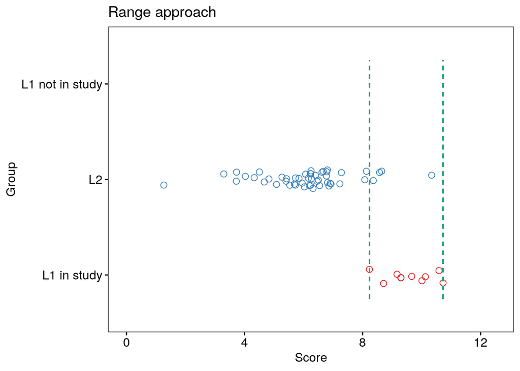

```r
df <- data.frame(Group = c(rep("L1 in study", 10),
                           rep("L2", 50),
                           rep("L1 not in study", 200)),
                 Score = c(L1_in_study, L2_in_study, L1_not_in_study))
df$Group <- factor(df$Group, levels = c("L1 in study", "L2", "L1 not in study"))

ggplot(df,
       aes(x = Score,
           y = Group,
           colour = Group)) +
  geom_point(shape = 1,
             position = position_jitter(height = 0.1),
             size = 2.5) +
  scale_colour_manual(values = c("#E41A1C", "#377EB8", NA)) +
  theme(legend.position = "none") +
  geom_segment(aes(x = min(L1_in_study),
                   xend = min(L1_in_study),
                   y = 0.75, yend = 3.25),
               colour = "#1B9E77",
               linetype = 2) +
  geom_segment(aes(x = max(L1_in_study),
                   xend = max(L1_in_study),
                   y = 0.75, yend = 3.25),
               colour = "#1B9E77",
               linetype = 2) +
  ggtitle("Range approach") +
  xlim(0, 12.5)
```

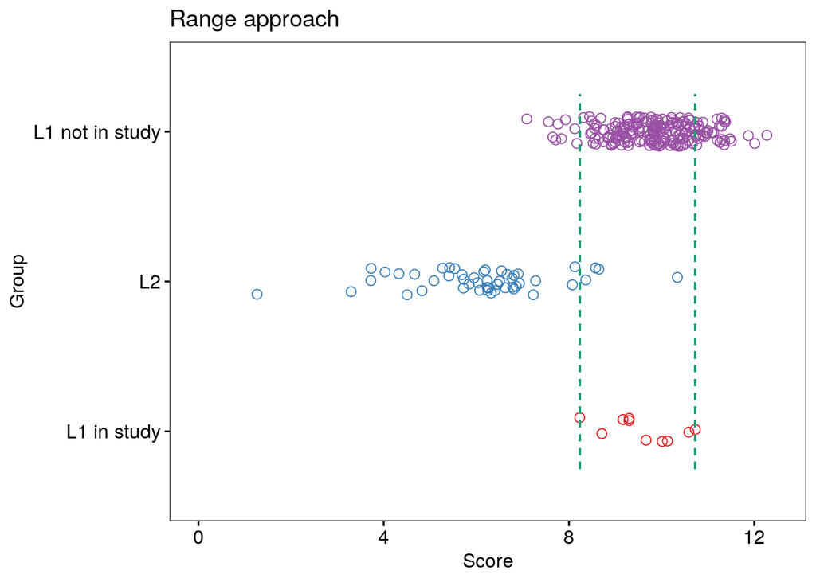

```r
ggplot(df,
       aes(x = Score,
           y = Group,
           colour = Group)) +
  geom_point(shape = 1,
             position = position_jitter(height = 0.1),
             size = 2.5) +
  scale_colour_manual(values = c("#E41A1C", "#377EB8", "#984ea3")) +
  theme(legend.position = "none") +
  geom_segment(aes(x = min(L1_in_study),
                   xend = min(L1_in_study),
                   y = 0.75, yend = 3.25),
               colour = "#1B9E77",
               linetype = 2) +
  geom_segment(aes(x = max(L1_in_study),
                   xend = max(L1_in_study),
                   y = 0.75, yend = 3.25),
               colour = "#1B9E77",
               linetype = 2) +
  ggtitle("Range approach") +
  xlim(0, 12.5)
```

## 2.2 Simulation: How bad could it be?

```r
# Define a function that generates one run of the simulation.
wrong_rejection <- function(n_control,
                            n_variables,
                            r) {
  # Generate data from multivariate
  # normal distribution (n_variables variables)
  # with all correlations = r and all standard deviations = 1

  # Specify variance-covariance matrix for multivariate distribution
  vcov_matrix <- matrix(data = r,
                        nrow = n_variables, ncol = n_variables)
  diag(vcov_matrix) <- 1

  # Draw the first sample (training, i.e., L1 speakers in study)
  training_sample <- MASS::mvrnorm(n = n_control,
                                   mu = rep(0, n_variables),
                                   Sigma = vcov_matrix)

  # New sample (test) from same distribution (L1 speakers not in study)
  test_sample <- MASS::mvrnorm(n = 10000,
                               mu = rep(0, n_variables),
                               Sigma = vcov_matrix)

  # How many participants in test sample
  # are not within all training sample ranges?
  minimum_range <- matrix(rep(apply(training_sample, 2, min), 10000),
                          ncol = n_variables, byrow = TRUE)
  maximum_range <- matrix(rep(apply(training_sample, 2, max), 10000),
                          ncol = n_variables, byrow = TRUE)
  nonnativelike_range <- rowSums(test_sample < minimum_range | test_sample > maximum_range) > 0

  # Same for standard deviations
  st_devs <- apply(training_sample, 2, sd)
  means <- apply(training_sample, 2, mean)
  minimum_sd <- matrix(rep(means - 2 * st_devs, 10000),
                       ncol = n_variables, byrow = TRUE)
  maximum_sd <- matrix(rep(means + 2 * st_devs, 10000),
                       ncol = n_variables, byrow = TRUE)
  nonnativelike_sd <- rowSums(test_sample < minimum_sd | test_sample > maximum_sd) > 0

  return(
    data.frame(
      range_criterion = mean(nonnativelike_range),
      sd_criterion = mean(nonnativelike_sd)
      )
    )
}
```

### 2.2.1 More elaborate version of simulation in talk

- 15 or 50 L1 participants
- 1, 2, 4, 8, 16 or 32 task scores
- task scores are fairly strongly (rho = 0.7) or fairly weakly (rho = 0.3) correlated

```r
# Grid with parameter combinations
n_grid <- expand.grid(n_control = c(15, 50),
                      r = c(0.3, 0.7),
                      n_variables = c(1, 2, 4, 8, 16, 32),
                      replicates = 1:1000)
n_grid$missrate_range <- NA
n_grid$missrate_sd <- NA

# Loop through grid and compute missrates.
# This takes a couple of minutes.
for (i in 1:nrow(n_grid)) {
  n_grid[i, 5:6] <- wrong_rejection(n_control = n_grid$n_control[i],
                                    n_variables = n_grid$n_variables[i],
                                    r = n_grid$r[i])[1:2]
  cat(i, "of", nrow(n_grid), "\n")
}

# Save results to disk
write_csv(n_grid, "nativelikeness_all.csv")
```

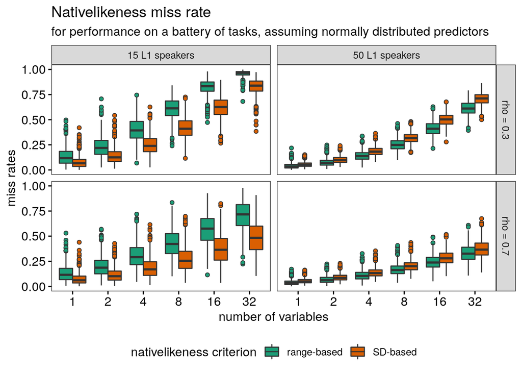

```r
# Wrangle results
false_rejections <- read.csv("nativelikeness_all.csv") %>%
  gather(key = "criterion",
         value = "missrate",
         missrate_range:missrate_sd)
false_rejections$criterion <- ifelse(false_rejections$criterion == "missrate_sd",
                                     "SD-based",
                                     "range-based")
false_rejections$r <- paste("rho =", false_rejections$r)
false_rejections$n_control <- paste(false_rejections$n_control, "L1 speakers")
false_rejections$n_variables <- factor(false_rejections$n_variables)

# Plot
ggplot(false_rejections,
       aes(x = n_variables,
           y = missrate,
           fill = criterion)) +
  geom_boxplot(outlier.shape = 21,
               position = position_dodge()) +
  xlab("number of variables") +
  ylab("miss rates") +
  facet_grid(r ~ reorder(n_control, -missrate)) +
  scale_fill_brewer(name = "nativelikeness criterion",
                    type = "qual", palette = "Dark2") +
  theme(legend.position = "bottom") +
  ggtitle("Nativelikeness miss rate",
          "for performance on a battery of tasks, assuming normally distributed predictors")
```

Note that the SD approach doesn’t have a uniformly lower miss rate than the range approach.

### 2.2.2 Simplified version

- 15 L1 speakers
- 1, 4, 16 task scores
- rho = 0.50

```r
# Grid with parameter combinations
n_grid <- expand.grid(n_control = 15,
                      r = 0.5,
                      n_variables = c(1, 4, 16),
                      replicates = 1:1000)
n_grid$missrate_range <- NA
n_grid$missrate_sd <- NA

# Loop through grid and compute missrates.
# This takes a couple of minutes.
for (i in 1:nrow(n_grid)) {
  n_grid[i, 5:6] <- wrong_rejection(n_control = n_grid$n_control[i],
                                    n_variables = n_grid$n_variables[i],
                                    r = n_grid$r[i])[1:2]
  cat(i, "of", nrow(n_grid), "\n")
}

# Save results to disk
write_csv(n_grid, "nativelikeness_reduced.csv")
```

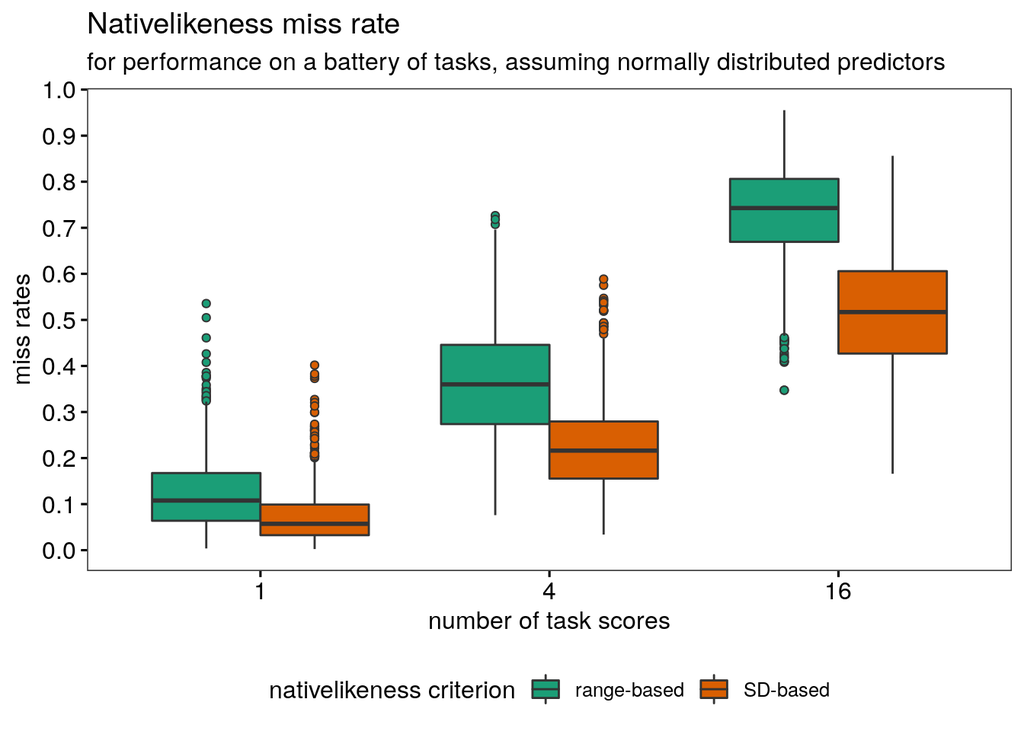

```r
# Wrangle results
false_rejections <- read.csv("nativelikeness_reduced.csv") %>%
  gather(key = "criterion",
         value = "missrate",
         missrate_range:missrate_sd)
false_rejections$criterion <- ifelse(false_rejections$criterion == "missrate_sd",
                                     "SD-based",
                                     "range-based")
false_rejections$r <- paste("rho =", false_rejections$r)
false_rejections$n_control <- paste(false_rejections$n_control, "L1 speakers")
false_rejections$n_variables <- factor(false_rejections$n_variables)

# Plot
ggplot(false_rejections,
       aes(x = n_variables,
           y = missrate,
           fill = criterion)) +
  geom_boxplot(outlier.shape = 21,
               position = position_dodge()) +
  xlab("number of task scores") +
  scale_y_continuous(breaks = seq(0, 1, 0.1)) +
  ylab("miss rates") +
  scale_fill_brewer(name = "nativelikeness criterion",
                    type = "qual", palette = "Dark2") +
  theme(legend.position = "bottom") +
  ggtitle("Nativelikeness miss rate",
          "for performance on a battery of tasks, assuming normally distributed predictors")
```

# 3 Using classification algorithms in nativelikeness studies

## 3.1 Data

Lacking a dataset on nativelikeness, I resort to a dataset on the Portuguese writing and reading skills of children who live in Portugal (“non-heritage speakers”) and children of Portuguese descent in Switzerland (“heritage speakers”). The data stem from Berthele and Vanhove (2017), Desgrippes et al. (2017), and Pestana et al. (2017). For illustration purposes, the goal of the analysis (but not of the original studies) is to determine how well the heritage and non-heritage speakers can be told apart on the basis of their performance on two writing tasks (argumentation and narration) and one reading task. Heritage speakers that are misclassified as non-heritage speakers can be said to be ‘non-heritagelike’, if you will, in much the same way that L2 speakers that are misclassified as L1 speakers could be said to be nativelike.

The dataset is available from http://janhove.github.io/datasets/heritagelikeness.csv. Download it to your R working directory and load it:

```r
d <- read.csv("heritagelikeness.csv")
```

The following graphs show how the two classes (heritage vs. non-heritage) compare in terms of their task scores.

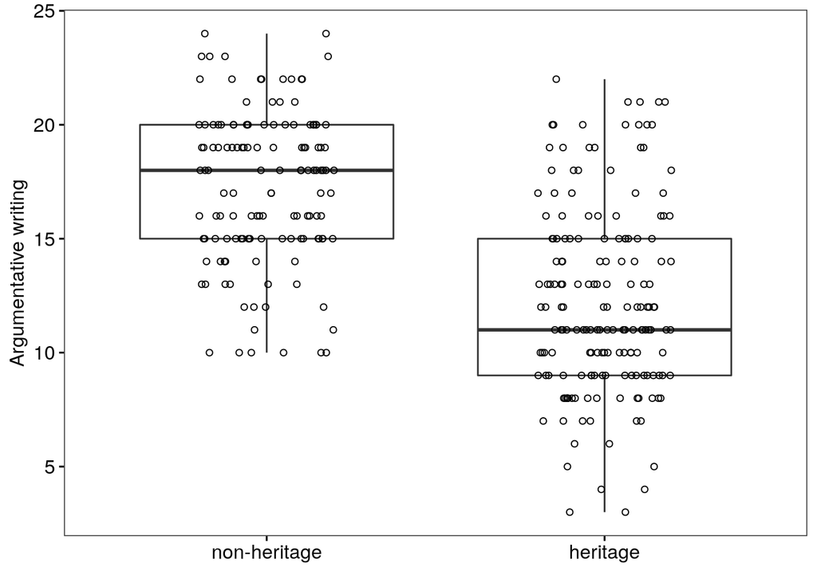

```r
ggplot(data = d,
       aes(x = HeritageSpeaker,
           y = Argumentation)) +
  geom_boxplot(outlier.shape = NA) +
  geom_point(shape = 1, position = position_jitter(height = 0, width = 0.2)) +
  scale_x_discrete(labels = c("non-heritage", "heritage")) +
  xlab(element_blank()) +
  ylab("Argumentative writing")
```

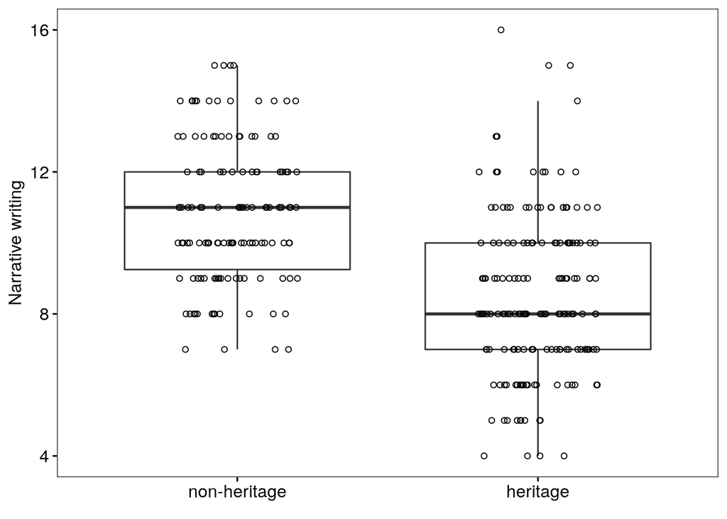

```r
ggplot(data = d,
       aes(x = HeritageSpeaker,
           y = Narration)) +
  geom_boxplot(outlier.shape = NA) +
  geom_point(shape = 1, position = position_jitter(width = 0.2, height = 0)) +
  scale_x_discrete(labels = c("non-heritage", "heritage")) +
  xlab(element_blank()) +
  ylab("Narrative writing")
```

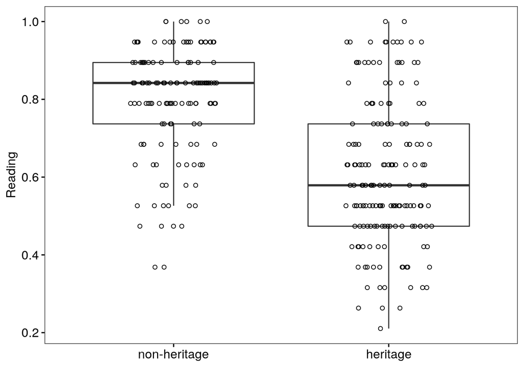

```r
ggplot(data = d,
       aes(x = HeritageSpeaker,
           y = Reading)) +
  geom_boxplot(outlier.shape = NA) +
  geom_point(shape = 1, position = position_jitter(width = 0.2, height = 0)) +
  scale_x_discrete(labels = c("non-heritage", "heritage")) +
  xlab(element_blank()) +
  ylab("Reading")
```

## 3.2 Models and algorithms

The results may vary slightly from run to run as some of the algorithms (specifically, the random forests) rely on randomly generated numbers.

Below I illustrate how four classification models/algorithms can be fitted on these data: logistic regression, classification trees (CART), CART-based random forests and conditional inference-based random forests. However, other algorithms and models exist (see Kuhn and Johnson, 2013), and it may be worth your while to experiment with these as well.

### 3.2.1 Add interaction predictors

Let’s add a couple of variables that represent the linear two- and three-way interactions between our three task scores. These new variables are just the products of the task scores:

```r
# Two-way interactions
d$ArgNarr <- d$Argumentation * d$Narration
d$ArgRead <- d$Argumentation * d$Reading
d$NarrRead <- d$Narration * d$Reading
# Three-way interaction
d$ArgNarrRead <- d$Argumentation * d$Narration * d$Reading
```

This step shouldn’t be necessary for training tree-based algorithms, but it enables models such as logistic regression to pick up on interactions between predictors.

### 3.2.2 Define cross-validation scheme

I’m using leave-one-out crossvalidation (LOOCV) here, but I don’t think any of the other options discussed in Kuhn and Johnson (2013, Section 4.4) are bad choices.

```r
ctrl <- trainControl(
  method = "LOOCV",
  summaryFunction = twoClassSummary,
  classProbs = TRUE,
  savePredictions = TRUE)
```

### 3.2.3 Logistic regression

The following code fits 305 logistic regression models. Each model leaves out a different data point. The class (heritage vs. non-heritage) of the data point left out of the model is then predicted on the basis of this model.

(ROC = the area under the receiver operating characteristic curve. The closer to 1 this number is, the better the model can separate the classes.)

```r
# Train model using the train() function from the caret package
# see ?train
lr <- train(x = d[, c("Argumentation", "Narration", "Reading",
                      "ArgNarr", "ArgRead", "NarrRead",
                      "ArgNarrRead")],
            y = d$HeritageSpeaker,
            method = "glm",
            metric = "ROC",
            trControl = ctrl)
lr
```

```
## Generalized Linear Model
##
## 305 samples
##   7 predictor
##   2 classes: 'no', 'yes'
##
## No pre-processing
## Resampling: Leave-One-Out Cross-Validation
## Summary of sample sizes: 304, 304, 304, 304, 304, 304, ...
## Resampling results:
##
##   ROC    Sens   Spec
##   0.834  0.761  0.778
```

```r
# Add classification probabilities to dataset
d$p_lr <- lr$pred$yes
```

Having obtained 305 classification probabilities, we can visualise how well the model can separate the two classes:

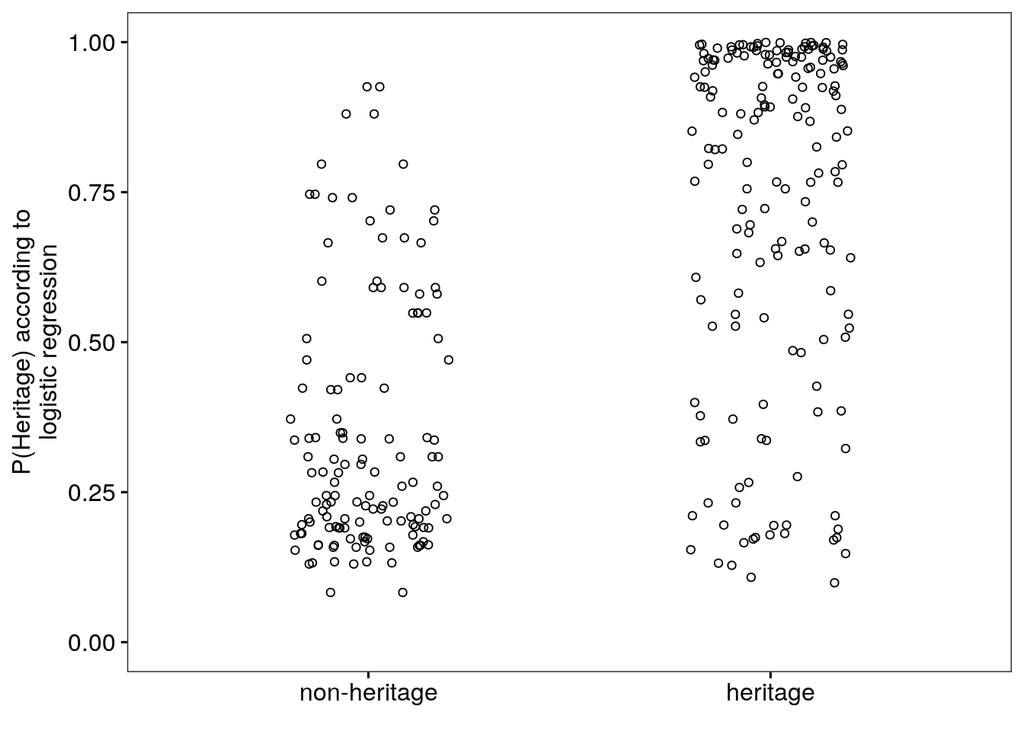

```r
ggplot(data = d,
       aes(x = HeritageSpeaker,
           y = p_lr)) +
  geom_point(shape = 1, position = position_jitter(width = 0.2, height = 0)) +
  scale_x_discrete(labels = c("non-heritage", "heritage")) +
  ylim(0, 1) +
  xlab(element_blank()) +
  ylab("P(Heritage) according to\nlogistic regression")
```

Regardless of where you draw a cut-off, you end up with some misclassifications:

```r
# Cut-off at p = 0.50
xtabs(~ (p_lr > 0.50) + HeritageSpeaker, data = d)
```

```
##           HeritageSpeaker
## p_lr > 0.5  no yes
##      FALSE 102  38
##      TRUE   32 133
```

38 out of (133 + 38 = 171) (i.e., 22%) of heritage speakers are ‘non-heritagelike’, and 32 out of (102 + 32 = 134) (i.e., 24%) of non-heritage speakers are ‘heritagelike’ if you apply a p = 0.50 threshold.

```r
# Cut-off at p = 0.75
xtabs(~ (p_lr > 0.75) + HeritageSpeaker, data = d)
```

```
##            HeritageSpeaker
## p_lr > 0.75  no yes
##       FALSE 128  67
##       TRUE    6 104
```

If you instead apply a p = 0.75 threshold, you only misclassify 4% of the non-heritage speakers, but now you end up misclassifying 39% of the heritage speakers.

```r
# Cut-off at p = 0.25
xtabs(~ (p_lr > 0.25) + HeritageSpeaker, data = d)
```

```
##            HeritageSpeaker
## p_lr > 0.25  no yes
##       FALSE  66  21
##       TRUE   68 150
```

Of course, if you can do without such thresholds and use the continuous classification probabilities as such, all the better.

To check if the prediction probabilities are well calibrated (see Kuhn and Johnson, 2013, Chapter 11), we can do the following.

- Split up the dataset into parts based on the classification probabilities. I split up the dataset into 5 parts (0-20%, 20-40% etc.) instead of 10, because there wouldn’t be a whole lot of data in some parts otherwise.
- Within each of these parts (bins), check which proportion of the dataset belongs to which class. Ideally, about 10% of the participants that are classified as heritage speakers with a probability of 0 to 20% should indeed be heritage speakers. Similarly, about 90% of the children that are classified as heritage speakers with a probability of 80 to 100% should indeed be heritage speakers.

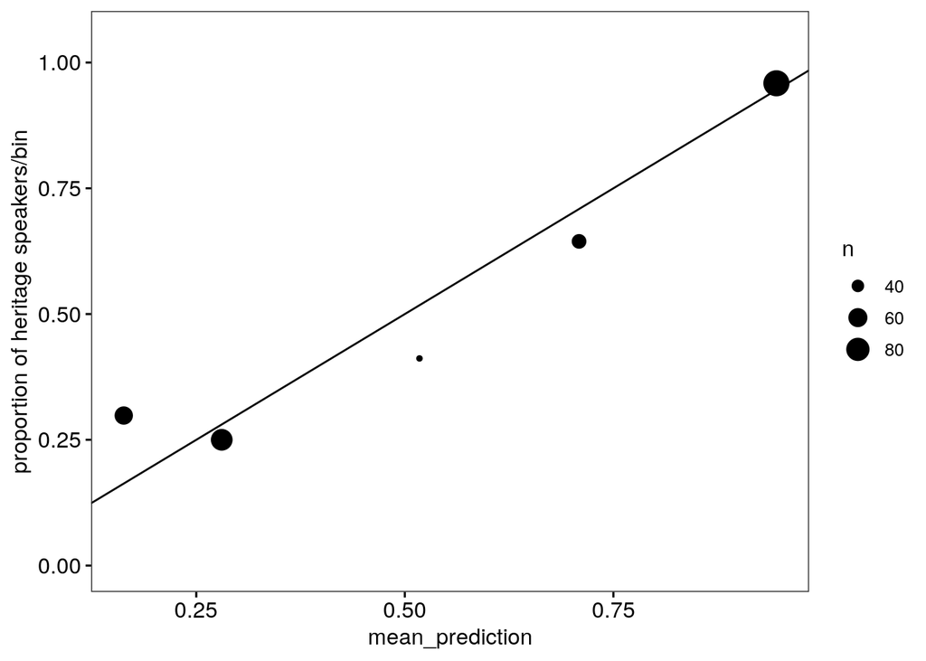

```r
# Create 5 bins (width = 0.20)
d$Bin <- cut(d$p_lr, breaks = seq(0, 1, by = 0.2),
             include.lowest = TRUE)

# Calculate proportion of heritage speakers
# in each bin:
perBin <- d %>%
  group_by(Bin) %>%
  summarise(
    # proportion of heritage speakers in bin
    prop_heritage = mean(HeritageSpeaker == "yes"),
    # number of observations in bin
    n = n(),
    # mean classification probability in bin
    mean_prediction = mean(p_lr)) %>%
  # Add the midpoints of the bins
  mutate(midpoint = seq(0.10, 0.90, length.out = 5))

# Plot
ggplot(perBin,
       aes(x = mean_prediction,
           y = prop_heritage,
           size = n)) +
  geom_point() +
  geom_abline(intercept = 0, slope = 1) +
  ylim(0, 1.05) +
  ylab("proportion of heritage speakers/bin")
```

The classification probabilities seem to be fairly well calibrated. You’d hope to find that the dots lie quite near the diagonal line, but deviations are to be expected due to the limited number of observations in each bin.

### 3.2.4 Classification and regression trees (CART)

The CART algorithm works entirely differently to logistic regression; let’s see how well it fares. In contrast to logistic regression, this algorithm has a “hyperparameter” called “cp” (complexity). (Read about it in Kuhn & Johnson’s book.) This hyperparameter can be tuned; I have found through cross-validation that a good setting for this particular dataset was `cp = 0`. See Kuhn and Johnson (2013) for more on model tuning.

```r
cart <- train(x = d[, c("Argumentation", "Narration", "Reading",
                        "ArgNarr", "ArgRead", "NarrRead",
                        "ArgNarrRead")],
              y = d$HeritageSpeaker,
              method = "rpart", tuneGrid = data.frame(cp = 0),
              metric = "ROC",
              trControl = ctrl)
cart
```

```
## CART
##
## 305 samples
##   7 predictor
##   2 classes: 'no', 'yes'
##
## No pre-processing
## Resampling: Leave-One-Out Cross-Validation
## Summary of sample sizes: 304, 304, 304, 304, 304, 304, ...
## Resampling results:
##
##   ROC    Sens   Spec
##   0.828  0.746  0.789
##
## Tuning parameter 'cp' was held constant at a value of 0
```

```r
d$p_cart <- cart$pred$yes
```

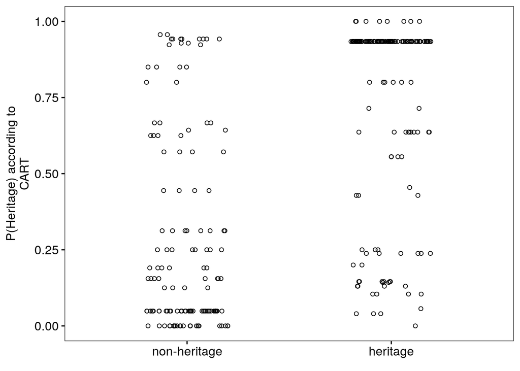

```r
ggplot(data = d,
       aes(x = HeritageSpeaker,
           y = p_cart)) +
  geom_point(shape = 1, position = position_jitter(width = 0.2, height = 0)) +
  scale_x_discrete(labels = c("non-heritage", "heritage")) +
  ylim(0, 1) +
  xlab(element_blank()) +
  ylab("P(Heritage) according to\nCART")
```

In terms of the area under the ROC, logistic regression and CART perform similarly. However, the classification probabilities for individual observations differ wildly between both procedures:

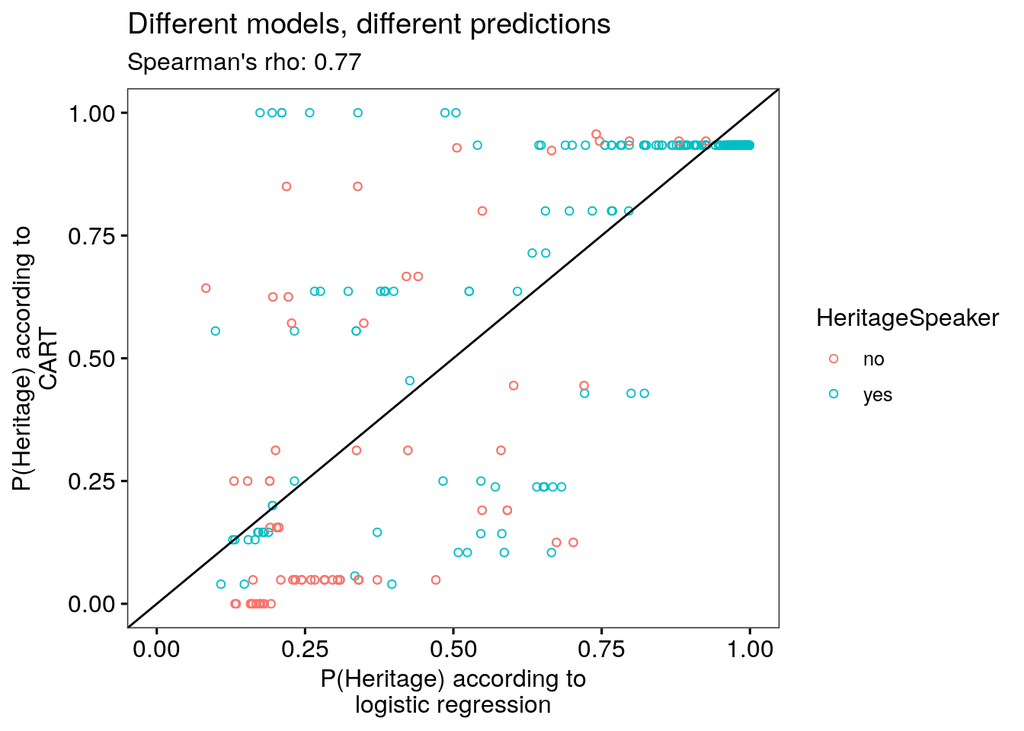

```r
ggplot(d,
       aes(x = p_lr,
           y = p_cart,
           colour = HeritageSpeaker)) +
  geom_point(shape = 1) +
  xlim(0, 1) +
  ylim(0, 1) +
  xlab("P(Heritage) according to\nlogistic regression") +
  ylab("P(Heritage) according to\nCART") +
  geom_abline(intercept = 0, slope = 1) +
  ggtitle("Different models, different predictions",
          subtitle = paste0("Spearman's rho: ", round(cor(d$p_lr, d$p_cart), 2)))
```

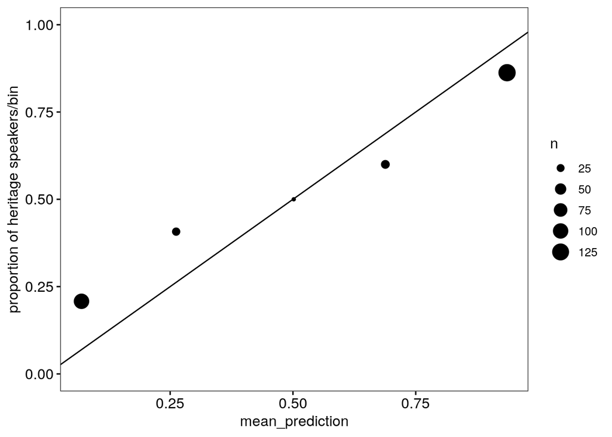

```r
d$Bin <- cut(d$p_cart, breaks = seq(0, 1, by = 0.2),
             include.lowest = TRUE)

perBin <- d %>%
  group_by(Bin) %>%
  summarise(
    prop_heritage = mean(HeritageSpeaker == "yes"),
    n = n(),
    mean_prediction = mean(p_cart)) %>%
  mutate(midpoint = seq(0.10, 0.90, length.out = 5))

ggplot(perBin,
       aes(x = mean_prediction,
           y = prop_heritage,
           size = n)) +
  geom_point() +
  geom_abline(intercept = 0, slope = 1) +
  ylim(0, 1) +
  ylab("proportion of heritage speakers/bin")
```

### 3.2.5 Random forests using CART

See my article for a quick breakdown of random forests. In terms of ROC performance, this algorithm blows logistic regression and CART out of the water. Crossvalidation suggested that the hyperparameter `mtry` was best fixed at 4 (though it mattered only little).

```r
rafo <- train(x = d[, c("Argumentation", "Narration", "Reading",
                        "ArgNarr", "ArgRead", "NarrRead",
                        "ArgNarrRead")],
              y = d$HeritageSpeaker,
              method = "rf",
              tuneGrid = data.frame(mtry = 4),
              ntree = 5000,
              metric = "ROC",
              trControl = ctrl)
rafo
```

```
## Random Forest
##
## 305 samples
##   7 predictor
##   2 classes: 'no', 'yes'
##
## No pre-processing
## Resampling: Leave-One-Out Cross-Validation
## Summary of sample sizes: 304, 304, 304, 304, 304, 304, ...
## Resampling results:
##
##   ROC    Sens   Spec
##   0.953  0.985  0.848
##
## Tuning parameter 'mtry' was held constant at a value of 4
```

```r
d$p_rafo <- rafo$pred$yes
```

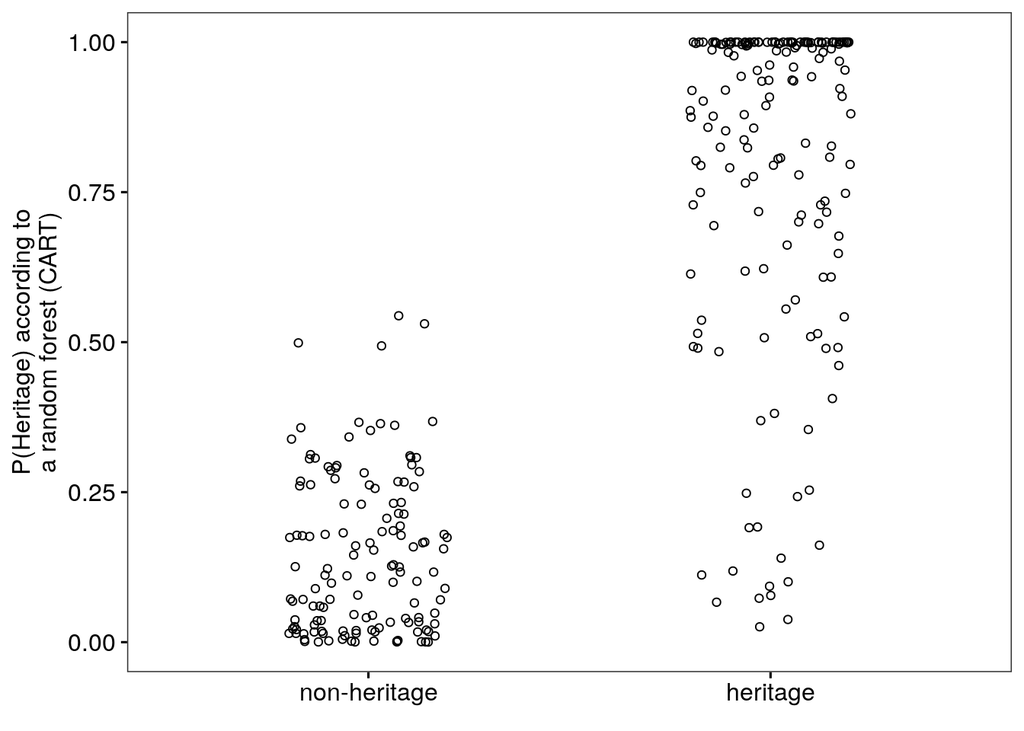

```r
ggplot(data = d,
       aes(x = HeritageSpeaker,
           y = p_rafo)) +
  geom_point(shape = 1, position = position_jitter(width = 0.2, height = 0)) +
  scale_x_discrete(labels = c("non-heritage", "heritage")) +
  ylim(0, 1) +
  xlab(element_blank()) +
  ylab("P(Heritage) according to\na random forest (CART)")
```

Its classification probabilities don’t seem to be well calibrated, however: If it outputs a 50% that a particular child is a heritage speaker, then the actual probability seems to be upwards of 75%! What this means is that the algorithm is capable of distinguishing between heritage and non-heritage speakers with good reliability, but that you shouldn’t take the individual probabilities that it outputs too literally.

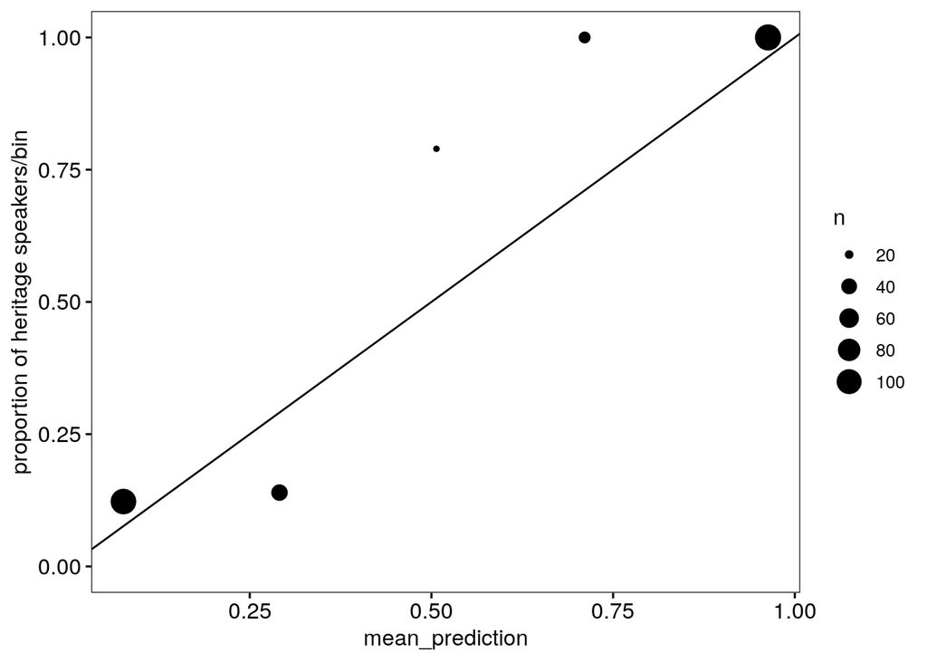

```r
d$Bin <- cut(d$p_rafo, breaks = seq(0, 1, by = 0.2),
             include.lowest = TRUE)

perBin <- d %>%
  group_by(Bin) %>%
  summarise(
    prop_heritage = mean(HeritageSpeaker == "yes"),
    n = n(),
    mean_prediction = mean(p_rafo)) %>%
  mutate(midpoint = seq(0.10, 0.90, length.out = 5))

ggplot(perBin,
       aes(x = mean_prediction,
           y = prop_heritage,
           size = n)) +
  geom_point() +
  geom_abline(intercept = 0, slope = 1) +
  ylim(0, 1) +
  ylab("proportion of heritage speakers/bin")
```

That said, some deviations are to be expected due to small sample sizes within each bin. You could compute confidence intervals around these proportions:

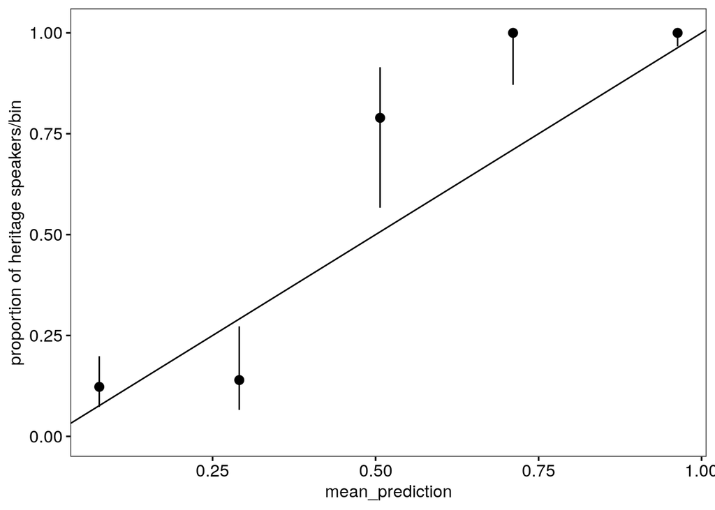

```r
perBin <- d %>%
  group_by(Bin) %>%
  summarise(prop_heritage = mean(HeritageSpeaker == "yes"),
            n = n(),
            mean_prediction = mean(p_rafo),
            CI_lo = Hmisc::binconf(sum(HeritageSpeaker == "yes"), n = n)[2],
            CI_hi = Hmisc::binconf(sum(HeritageSpeaker == "yes"), n = n)[3]) %>%
  mutate(midpoint = seq(0.1, 0.9, length.out = 5))

ggplot(perBin,
       aes(x = mean_prediction,
           y = prop_heritage,
           ymin = CI_lo,
           ymax = CI_hi)) +
  geom_pointrange() +
  geom_abline(intercept = 0, slope = 1) +
  ylim(0, 1.01) +
  ylab("proportion of heritage speakers/bin")
```

### 3.2.6 Random forest using conditional inferencing

Another flavour of random forests. `mtry = 6` worked best in crossvalidation. This type of random forest didn’t work as well in terms of ROC, but it may have some use (see below).

```r
cfor <- train(x = d[, c("Argumentation", "Narration", "Reading",
                      "ArgNarr", "ArgRead", "NarrRead",
                      "ArgNarrRead")],
            y = d$HeritageSpeaker,
            method = "cforest",
            tuneGrid = data.frame(mtry = 6),
            metric = "ROC",
            trControl = ctrl)
cfor
```

```
## Conditional Inference Random Forest
##
## 305 samples
##   7 predictor
##   2 classes: 'no', 'yes'
##
## No pre-processing
## Resampling: Leave-One-Out Cross-Validation
## Summary of sample sizes: 304, 304, 304, 304, 304, 304, ...
## Resampling results:
##
##   ROC    Sens   Spec
##   0.882  0.858  0.754
##
## Tuning parameter 'mtry' was held constant at a value of 6
```

```r
d$p_cfor <- cfor$pred$yes
```

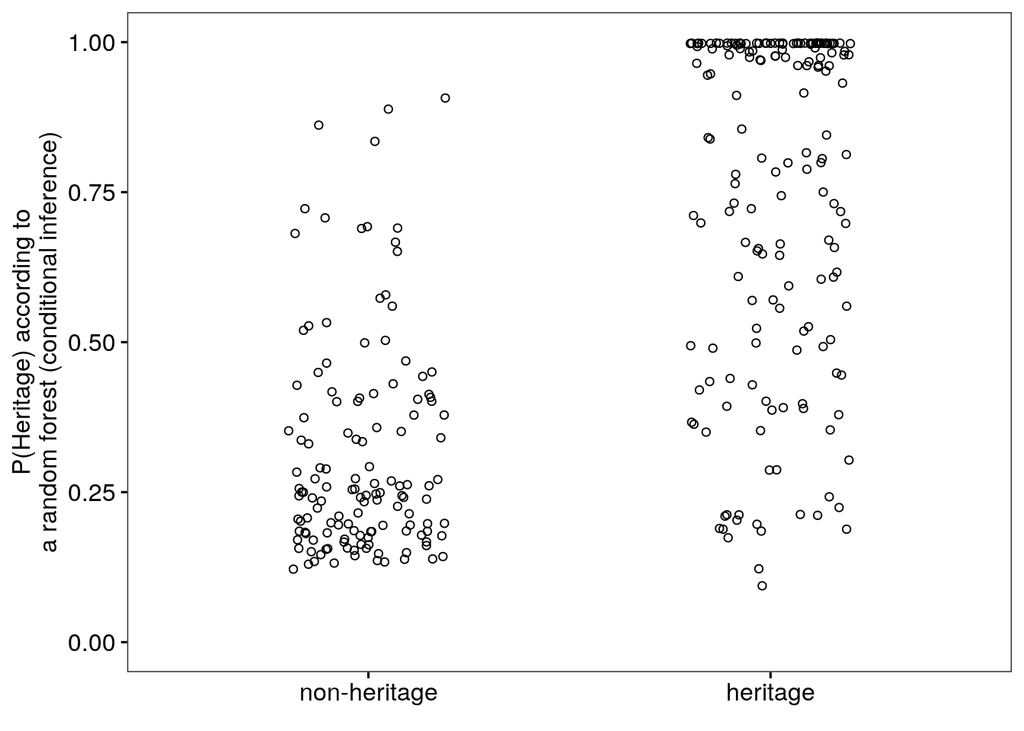

```r
ggplot(data = d,
       aes(x = HeritageSpeaker,
           y = p_cfor)) +
  geom_point(shape = 1, position = position_jitter(width = 0.2, height = 0)) +
  scale_x_discrete(labels = c("non-heritage", "heritage")) +
  ylim(0, 1) +
  xlab(element_blank()) +
  ylab("P(Heritage) according to\na random forest (conditional inference)")
```

Another illustration that different models yield different predictions for individual cases:

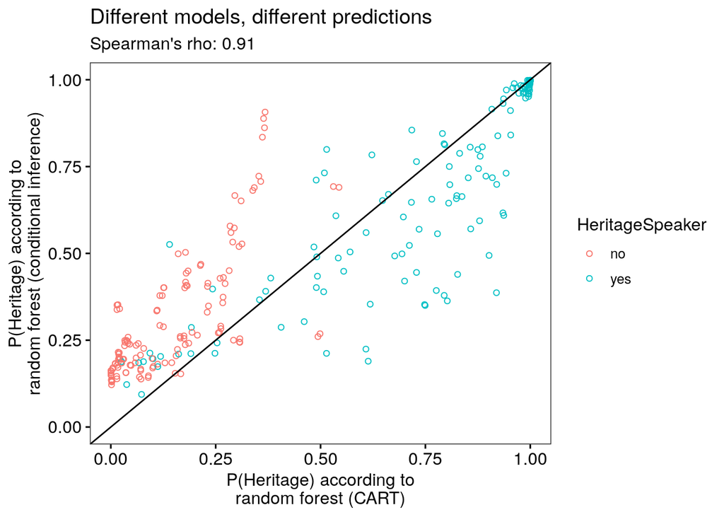

```r
ggplot(d,
       aes(x = p_rafo,
           y = p_cfor,
           colour = HeritageSpeaker)) +
  geom_point(shape = 1) +
  xlim(0, 1) +
  ylim(0, 1) +
  xlab("P(Heritage) according to\nrandom forest (CART)") +
  ylab("P(Heritage) according to\nrandom forest (conditional inference)") +
  geom_abline(intercept = 0, slope = 1) +
  ggtitle("Different models, different predictions",
          subtitle = paste0("Spearman's rho: ", round(cor(d$p_rafo, d$p_cfor), 2)))
```

## 3.3 Model stacking

It is sometimes possible to obtain better predictions still by building meta-models: You use the classification probabilities output by the models you fitted to fit another classification model. This is known as ‘model stacking’.

Here I fit a random forest using the four probability vectors obtained using the ‘base’ models. Cross-validation suggested that `mtry = 1` works best. This stacked model outperforms the ‘base’ random forest in terms of area under the ROC curve.

```r
stack.rf <- train(x = d[, c("p_lr", "p_cart", "p_rafo", "p_cfor")],
            y = d$HeritageSpeaker,
            method = "rf",
            tuneGrid = data.frame(mtry = 1),
            ntree = 5000,
            metric = "ROC",
            trControl = ctrl)
stack.rf
```

```
## Random Forest
##
## 305 samples
##   4 predictor
##   2 classes: 'no', 'yes'
##
## No pre-processing
## Resampling: Leave-One-Out Cross-Validation
## Summary of sample sizes: 304, 304, 304, 304, 304, 304, ...
## Resampling results:
##
##   ROC    Sens   Spec
##   0.986  0.985  0.936
##
## Tuning parameter 'mtry' was held constant at a value of 1
```

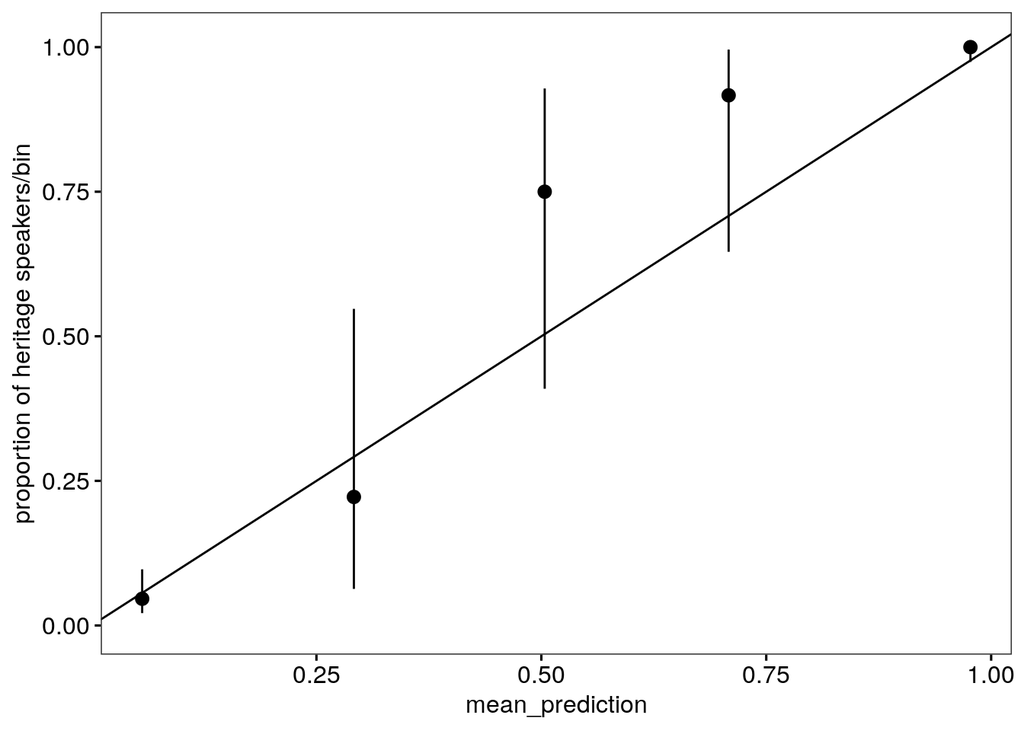

```r
d$p_stack.rf <- stack.rf$pred$yes

d$Bin <- cut(d$p_stack.rf, breaks = seq(0, 1, by = 0.2),
             include.lowest = TRUE)

perBin <- d %>%
  group_by(Bin) %>%
  summarise(prop_heritage = mean(HeritageSpeaker == "yes"),
            n = n(),
            CI_lo = Hmisc::binconf(sum(HeritageSpeaker == "yes"), n = n)[2],
            CI_hi = Hmisc::binconf(sum(HeritageSpeaker == "yes"), n = n)[3],
            mean_prediction = mean(p_stack.rf)) %>%
  mutate(midpoint = seq(0.1, 0.9, length.out = 5))

ggplot(perBin,
       aes(x = mean_prediction,
           y = prop_heritage,
           ymin = CI_lo,
           ymax = CI_hi)) +
  geom_pointrange() +
  geom_abline(intercept = 0, slope = 1) +
  ylim(0, 1.01) +
  ylab("proportion of heritage speakers/bin")
```

The classification probabilities don’t look too well calibrated in the middle part of the probability range, but that’s mainly because there’s hardly any data there: there are hardly any children for whom the model is completely undecided: There are only 29 (out of 305) children with classification probabilities between 0.20 and 0.80. (These numbers differ from the ones in the talk due to the randomness inherent in fitting these models.)

```r
perBin
```

```
## # A tibble: 5 x 7
##   Bin       prop_heritage     n  CI_lo  CI_hi mean_prediction midpoint
##   <fct>             <dbl> <int>  <dbl>  <dbl>           <dbl>    <dbl>
## 1 [0,0.2]          0.0462   130 0.0213 0.0970          0.0563      0.1
## 2 (0.2,0.4]        0.222      9 0.0632 0.547           0.292       0.3
## 3 (0.4,0.6]        0.75       8 0.409  0.929           0.504       0.5
## 4 (0.6,0.8]        0.917     12 0.646  0.996           0.708       0.7
## 5 (0.8,1]          1        146 0.974  1.              0.977       0.9
```

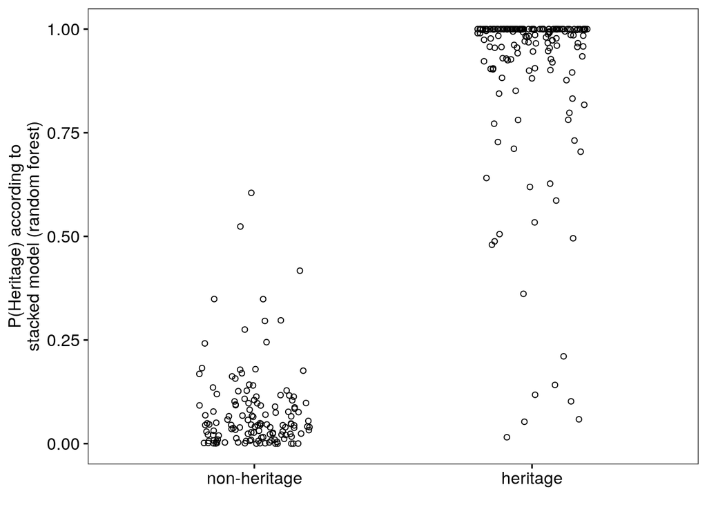

```r
ggplot(data = d,
       aes(x = HeritageSpeaker,
           y = p_stack.rf)) +
  geom_point(shape = 1, position = position_jitter(width = 0.2, height = 0)) +
  scale_x_discrete(labels = c("non-heritage", "heritage")) +
  ylim(0, 1) +
  xlab(element_blank()) +
  ylab("P(Heritage) according to\nstacked model (random forest)")
```

If you apply a p = 0.50 threshold for non-heritagelikeness, you end up miscategorising (only) 2 out of 134 non-heritage speakers as heritagelike (1.5%), whilst 11 out of 171 (6%) of heritage speakers are labelled as non-heritagelike. If you set the bar higher, none of the non-heritage speakers are misclassified. Note, however, that these models still assign some probability of being (non-)heritagelike to many children.

```r
# Cut-off at p = 0.50
xtabs(~ (p_stack.rf > 0.50) + HeritageSpeaker, data = d)
```

```
##                 HeritageSpeaker
## p_stack.rf > 0.5  no yes
##            FALSE 132  11
##            TRUE    2 160
```

A final important remark: If you want to apply a cut-off point for distinguishing nativelike from nonnativelike speakers, don’t set this cut-off on the basis of the classification probabilities in the dataset you analysed (like I did above by way of illustration); see Ewald (2006). You either need to predefine the cut-off or validate it using new data.

# 4 References

This list includes references in the talk that aren’t mentioned on this page.

Abrahamsson, Niclas and Kenneth Hyltenstam. 2009. Age of onset and nativelikeness in a second language: Listener perception versus linguistic scrutiny. *Language Learning* 59. 249-306. [doi:10.1111/j.1467-9922.2009.00507.x](http://dx.doi.org/10.1111/j.1467-9922.2009.00507.x)

Andringa, Sible. 2014. The use of native speaker norms in critical period hypothesis research. *Studies in Second Language Acquisition* 36(3). 565-596. [doi:10.1017/S0272263113000600](http://dx.doi.org/10.1017/S0272263113000600)

Birdsong, David. 2005. Interpreting age effects in second language acquisition. In: Judith F. Kroll and Annette M. B. de Groot (eds), *Handbook of bilingualism: Psycholinguistic approaches* (pp. 109-127). New York, NY: Oxford University Press.

Birdsong, David and Libby M. Gertken. 2013. In faint praise of folly: A critical review of native/non-native speaker comparisons, with examples from native and bilingual processing of French complex syntax. *Language, Interaction and Acquisition* 4(2). 107-133. [doi:10.1075/lia.4.2.01bir](http://dx.doi.org/10.1075/lia.4.2.01bir)

Cook, Vivian J. 1992. Evidence for multicompetence. *Language Learning* 42. 557-591.

Dąbrowska, Ewa. 2012. Different speakers, different grammars: Individual differences in native language attainment. *Linguistic Approaches to Bilingualism* 2(3). 219-253. [doi:10.1075/lab.2.3.01dab](http://dx.doi.org/10.1075/lab.2.3.01dab)

Davies, Alan. 2003. *The native speaker: Myth and reality*. Clevedon, UK: Multilingual Matters.

Desgrippes, Magalie, Amelia Lambelet and Jan Vanhove. 2017. The development of argumentative and narrative writing skills in Portuguese heritage speakers in Switzerland (HELASCOT project). In: Raphael Berthele and Amelia Lambelet (eds), *Heritage and school language literacy development in migrant children: Interdependence or independence?* (pp. 83-96). Bristol, UK: Multilingual Matters.

Ewald, Ben. 2006. Post hoc choice of cut points introduced bias to diagnostic research. *Journal of Clinical Epidemiology* 59(8). 798-801. [doi:10.1016/j.jclinepi.2005.11.025](http://dx.doi.org/10.1016/j.jclinepi.2005.11.025)

Grosjean, François. 1989. Neurolinguists, beware! The bilingual is not two monolinguals in one person. *Brain and Language* 36. 3-15.

Hyltenstam, Kenneth and Niclas Abrahamsson. 2003. Maturational constraints in SLA. In: Catherine J. Doughty and Michael H. Long (eds), *The handbook of second language acquisition* (pp. 539-588). Malden, MA: Blackwell.

Kuhn, Max and Kjell Johnson. 2013. *Applied predictive modeling*. New York, NY: Springer.

Long, Michael H. 2005. Problems with supposed counter-evidence to the critical period hypothesis. *International Review of Applied Linguistics in Language Teaching* 43. 287-317. [doi:10.1515/iral.2005.43.4.287](http://dx.doi.org/10.1515/iral.2005.43.4.287)

Ortega, Lourdes. 2013. SLA for the 21st century: Disciplinary progress, transdisciplinary relevance, and the bi/multilingual turn. *Language Learning* 63(s1). 1-24. [doi:10.1111/j.1467-9922.2012.00735.x](http://dx.doi.org/10.1111/j.1467-9922.2012.00735.x)

Pestana, Carlos, Amelia Lambelet and Jan Vanhove. 2017. Reading comprehension development in Portuguese heritage speakers in Switzerland (HELASCOT project). In: Raphael Berthele and Amelia Lambelet (eds), *Heritage and school language literacy development in migrant children: Interdependence or independence?* (pp. 58-82). Bristol, UK: Multilingual Matters.

Vanhove, Jan. 2019. When labeling L2 users as nativelike or not, consider classification errors. *Second Language Research*. [doi:10.1177/0267658319827055](http://dx.doi.org/10.1177/0267658319827055)

Vanhove, Jan and Raphael Berthele. 2017. Testing the interdependence of languages (HELASCOT project). In: Raphael Berthele and Amelia Lambelet (eds), *Heritage and school language literacy development in migrant children: Interdependence or independence?* (pp. 97-118). Bristol, UK: Multilingual Matters.

Yarkoni, Tal and Jacob Westfall. 2017. Choosing prediction over explanation in psychology: Lessons from machine learning. *Perspectives on Psychological Science* 12(6). 1100-1122. [doi:10.1177/1745691617693393](http://dx.doi.org/10.1177/1745691617693393)